# SML201 Chapter 2.4

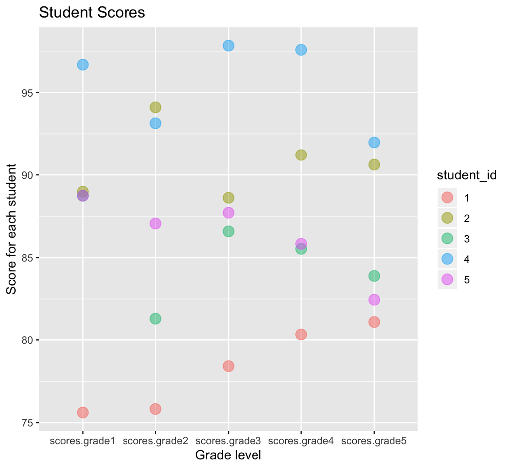

```r
# If there were no temporal relationship between the x-values
# (e.g., if the scores were for different subjects), you can
# also display the scores with dots
ggplot(per.student) + geom_point(mapping = aes(x = grade_level,
y = score, color = student_id), alpha=.5, size=4) +
labs(x = "Grade level", y = "Score for each student", title='Student Scores')
```

Now you understand what you are supposed to do to transform the dataset into a new data frame that is suitable for `ggplot()` we will show you how to use the function in the `reshape` package to do this automatically:

```r
library(reshape2)
long.grade <- melt(grade)
head(long.grade, n = 10)
```

|  | Var1 | Var2 | value |
| --- | --- | --- | --- |
| 1 | student1 | scores.grade1 | 75.61129 |
| 2 | student2 | scores.grade1 | 88.97910 |
| 3 | student3 | scores.grade1 | 88.73358 |
| 4 | student4 | scores.grade1 | 96.68129 |
| 5 | student5 | scores.grade1 | 88.74068 |
| 6 | student1 | scores.grade2 | 75.82484 |
| 7 | student2 | scores.grade2 | 94.10457 |
| 8 | student3 | scores.grade2 | 81.27816 |
| 9 | student4 | scores.grade2 | 93.14097 |
| 10 | student5 | scores.grade2 | 87.05681 |

```r
class(long.grade)
[1] "data.frame"
names(long.grade) = c("student_id", "grade_level", "score")
head(long.grade)  # same as the data frame that we created manually
```

|  | student_id | grade_level | score |
| --- | --- | --- | --- |
| 1 | student1 | scores.grade1 | 75.61129 |
| 2 | student2 | scores.grade1 | 88.97910 |
| 3 | student3 | scores.grade1 | 88.73358 |
| 4 | student4 | scores.grade1 | 96.68129 |
| 5 | student5 | scores.grade1 | 88.74068 |
| 6 | student1 | scores.grade2 | 75.82484 |

To put the data back to the original tidy format we can use the function `dcast()` in the `reshape` package.

```r
# This displays the values of one variable for the dataset
# and the info from the other two variables are shown in the
# row and column names
wide.grade <- dcast(long.grade, student_id ~ grade_level)
head(wide.grade)
```

|  | student_id | scores.grade1 | scores.grade2 | scores.grade3 | scores.grade4 | scores.grade5 |
| --- | --- | --- | --- | --- | --- | --- |
| 1 | student1 | 75.61129 | 75.82484 | 78.41237 | 80.32333 | 81.07747 |
| 2 | student2 | 88.97910 | 94.10457 | 88.61161 | 91.21141 | 90.61836 |
| 3 | student3 | 88.73358 | 81.27816 | 86.58292 | 85.52735 | 83.89072 |
| 4 | student4 | 96.68129 | 93.14097 | 97.83177 | 97.57671 | 91.98019 |
| 5 | student5 | 88.74068 | 87.05681 | 87.70862 | 85.83057 | 82.45199 |

```r
# note that the output of `dcast()` is still a data frame
class(wide.grade)
[1] "data.frame"
```

## Setting the x- and y- variables for your graphs globally

```r
ggplot(data = compl.air) + geom_boxplot(mapping = aes(x = factor(Month),
    y = Ozone, fill = factor(Month))) + geom_point(mapping = aes(x = factor(Month),
    y = Ozone)) + labs(title = "Ozone Level by Month for N.Y. State, May-Sept., 1973",
    x = "Month", y = "Ozone Level")


# The following line returns the same result as the line
# above
ggplot(data = compl.air, mapping = aes(x = factor(Month), y = Ozone)) +
    geom_boxplot(mapping = aes(fill = factor(Month))) + geom_point() +
    labs(title = "Ozone Level by Month for N.Y. State, May-Sept., 1973",
        x = "Month", y = "Ozone Level")
```

[output not shown]

## Using the jitter function

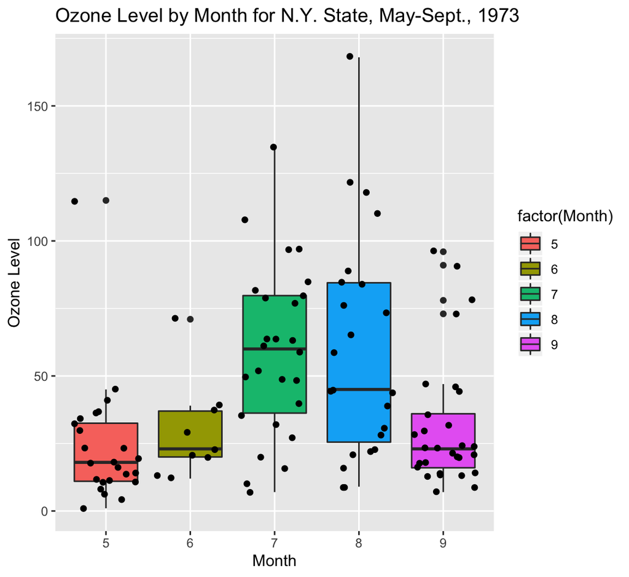

```r
g + geom_boxplot(mapping = aes(x = factor(Month), y = Ozone,
    fill = factor(Month))) + geom_jitter(mapping = aes(x = factor(Month),
    y = Ozone)) + labs(title = "Ozone Level by Month for N.Y. State, May-Sept., 1973",
    x = "Month", y = "Ozone Level")
```

We use `jitter()` to distinguish overlapping points; however, the spread for jittered data in the previous graph is too big.

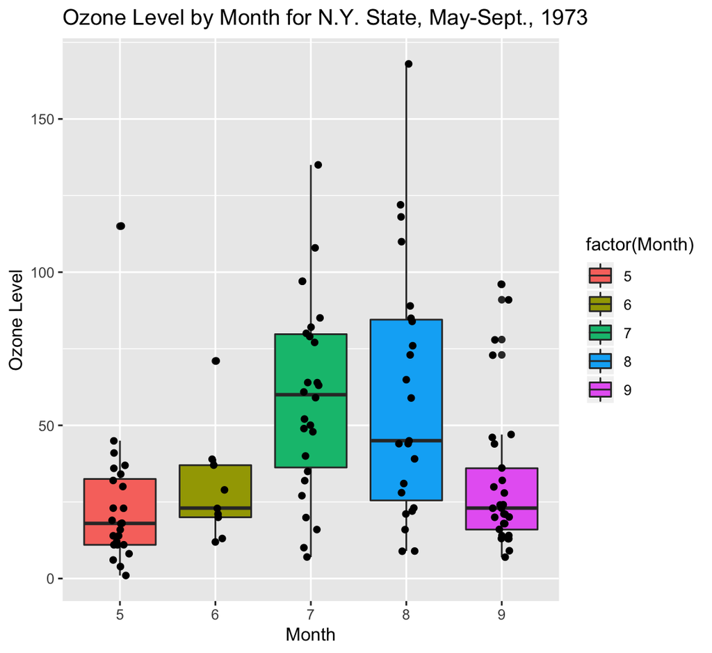

```r
g + geom_boxplot(mapping = aes(x = factor(Month), y = Ozone,
    fill = factor(Month))) + geom_jitter(mapping = aes(x = factor(Month),
    y = Ozone), width = 0.1, height = 0.1) + labs(title = "Ozone Level by Month for N.Y. State, May-Sept., 1973",
    x = "Month", y = "Ozone Level")
```

`width` and `height` adjust the amount of jitter.

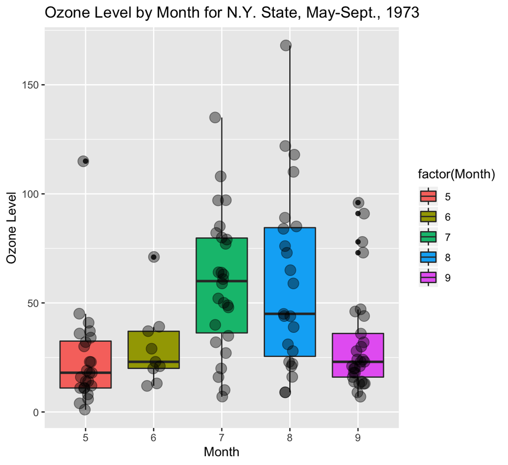

```r
ggplot(data = compl.air, mapping = aes(x = factor(Month), y = Ozone)) +
    geom_boxplot(mapping = aes(fill = factor(Month))) + geom_jitter(width = 0.1,
    height = 0.1, alpha = 0.4, size = 4) + labs(title = "Ozone Level by Month for N.Y. State, May-Sept., 1973",
    x = "Month", y = "Ozone Level")
```

`alpha` controls transparency; `size` controls the size of the dots.

## Adjust the variables for the theme

We can also make the title bold faced, change its color and adjust the height of the line between the two lines in the title. Note that we use `\n` to break the line of the title into two lines.

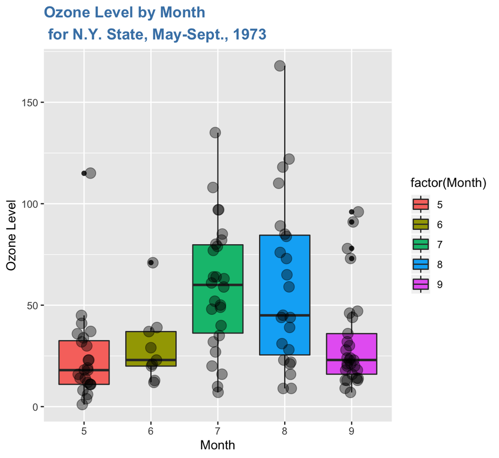

```r
ggplot(data = compl.air, mapping = aes(x = factor(Month), y = Ozone)) +
    geom_boxplot(mapping = aes(fill = factor(Month))) + geom_jitter(width = 0.1,
    height = 0.1, alpha = 0.4, size = 4) + labs(title = "Ozone Level by Month \n for N.Y. State, May-Sept., 1973",
    x = "Month", y = "Ozone Level") + theme(plot.title = element_text(face = "bold",
    color = "steelblue", lineheight = 1.2))
```

## Set theme locally

You can set the theme for your graph locally by adding a layer for the theme

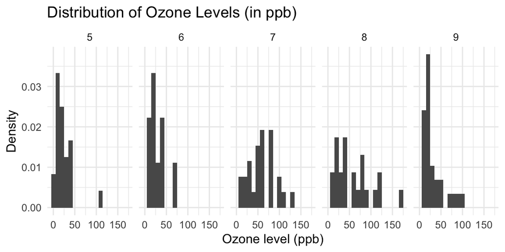

```r
# use the minimal theme
g + geom_histogram(mapping = aes(x=Ozone, ..density..),
                   binwidth=10) +
  labs(x = "Ozone level (ppb)",y = "Density",
       title = "Distribution of Ozone Levels (in ppb)") +
  facet_grid(.~Month) + theme_minimal()
```

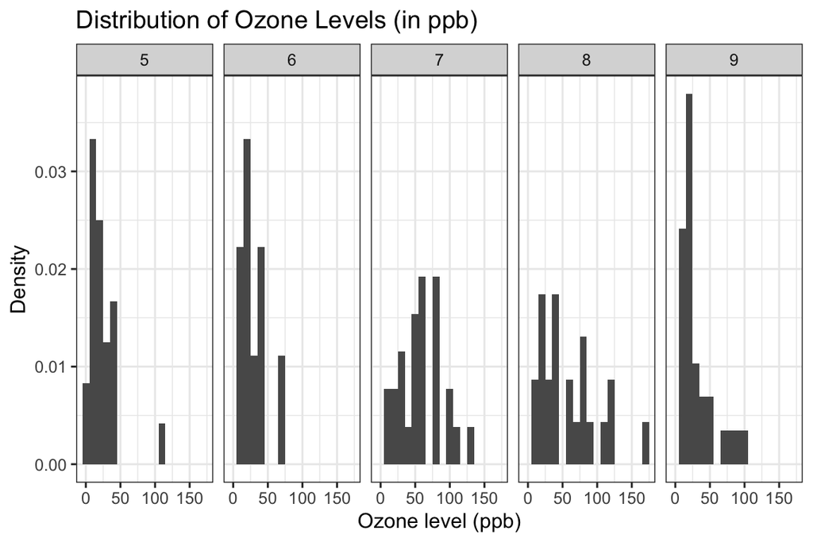

```r
g + geom_histogram(mapping = aes(x=Ozone, ..density..),
                   binwidth=10) +
  labs(x = "Ozone level (ppb)",y = "Density",
       title = "Distribution of Ozone Levels (in ppb)") +
  facet_grid(.~Month) + theme_bw()
```

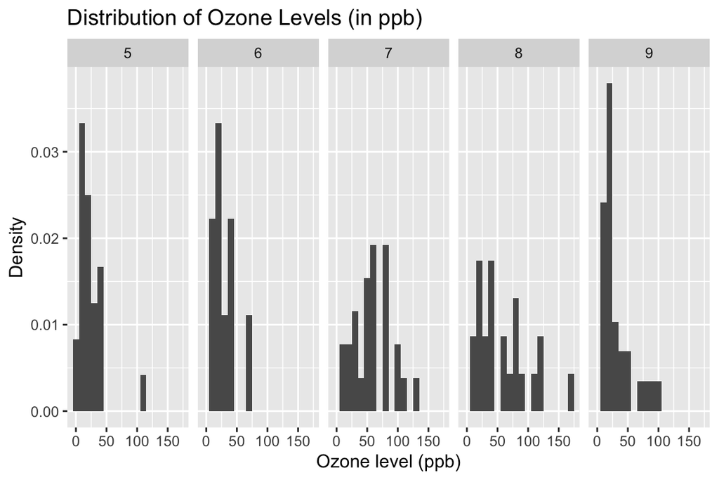

```r
g + geom_histogram(mapping = aes(x=Ozone, ..density..),
                   binwidth=10) +
  labs(x = "Ozone level (ppb)",y = "Density",
       title = "Distribution of Ozone Levels (in ppb)") +
  facet_grid(.~Month) + theme_grey()
```

## Set theme globally

You can also set the theme globally by using the `theme_set()` function

theme_set(theme_bw())  
theme_set(theme_grey())  
theme_set(theme_minimal())

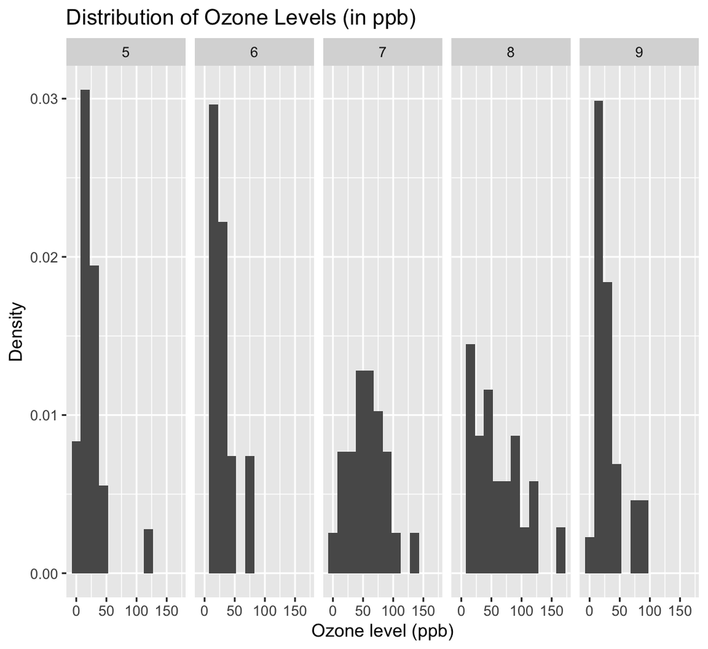

```r
theme_set(theme_grey())

g + geom_histogram(mapping = aes(x = Ozone, ..density..), binwidth = 15) +
    labs(x = "Ozone level (ppb)", y = "Density", title = "Distribution of Ozone Levels (in ppb)") +
    facet_grid(. ~ Month)
```